# IODS course project

##### Freetime

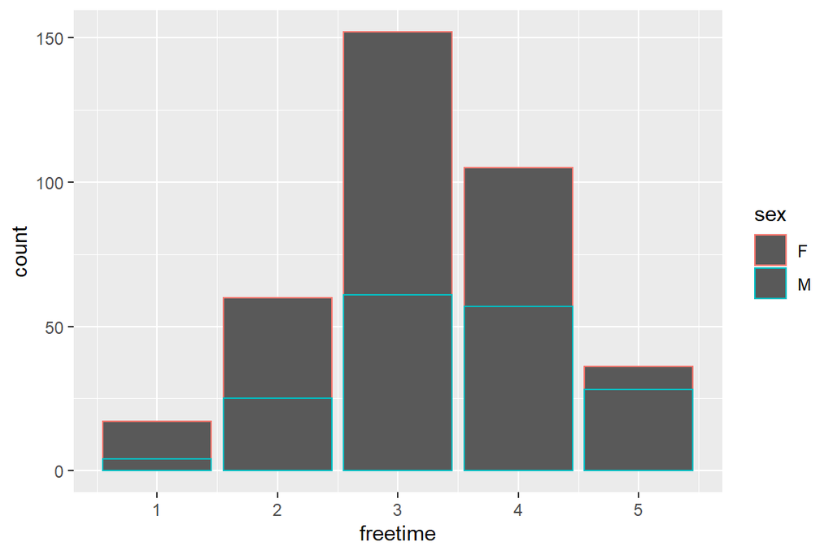

```r
g6 <- ggplot(alc_consump, aes(x=freetime, col=sex))#Freetime bar plot
g6 + geom_bar()
```

Most of the students have medium amount of freetime but females have a bit less freetime than males. And in males, high alcohol users have more freetime on average. In females the variance of freetime in high alcohol users is smaller than in low users. This was also as I assumed in my hypothesis.

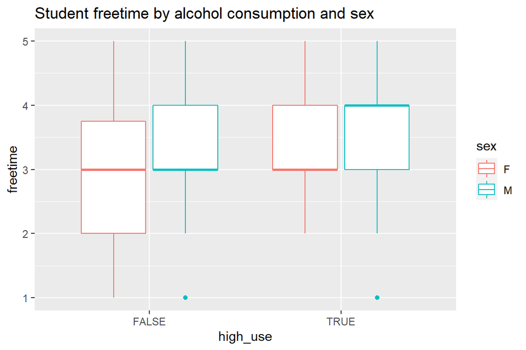

```r
g7 <- ggplot(alc_consump, aes(x = high_use, y = freetime, col=sex)) #box plot of high use vs freetime
g7 + geom_boxplot() + ylab("freetime") +ggtitle("Student freetime by alcohol consumption and sex")
```

#### Logistic regression

I will use logistic regression to statistically explore the relationship between my chosen variables: sex, grades, absences and freetime and the binary high/low alcohol consumption variable as the target variable.

```r
m1 <- glm(high_use ~ G3 + absences + sex + freetime, data = alc_consump, family = "binomial")
summary(m1)
```

```
##
## Call:
## glm(formula = high_use ~ G3 + absences + sex + freetime, family = "binomial",
##     data = alc_consump)
##
## Deviance Residuals:
##     Min       1Q   Median       3Q      Max
## -1.9992  -0.8376  -0.5967   1.0688   2.1281
##
## Coefficients:
##             Estimate Std. Error z value Pr(>|z|)
## (Intercept) -1.92263    0.63340  -3.035  0.00240 **
## G3          -0.07636    0.03706  -2.061  0.03935 *
## absences     0.09410    0.02323   4.050 5.12e-05 ***
## sexM         0.92938    0.25150   3.695  0.00022 ***
## freetime     0.30444    0.12845   2.370  0.01778 *
## ---
## Signif. codes:  0 '***' 0.001 '**' 0.01 '*' 0.05 '.' 0.1 ' ' 1
##
## (Dispersion parameter for binomial family taken to be 1)
##
##     Null deviance: 452.04  on 369  degrees of freedom
## Residual deviance: 405.20  on 365  degrees of freedom
## AIC: 415.2
##
## Number of Fisher Scoring iterations: 4
```

If we now look at the summary of the fitted model, we can see the model estimates and parameters and also the p-values of the statistical test (Pr(>|z|)). If we look at the p-values, all of them are smaller that 0,05, so all of the chosen variables are statistically significant. If we compare the p-values, grades (G3) has the highest value 0,0393 which is quite close to 0,05. So with grades the significance is not so great as for example in the case of absences. The p-value for absences is very small 5.12e-05, which means that there is statistically significant relationship between absences and high alcohol consumption. In the summary sexM, means that when comparing females to males, male sex has statistically significant relationship between high alcohol consumption, p-value 0,00022. However, there are statistically significant relationships between all the chosen variables and high alcohol consumption.

Next I will present the coefficients of the model as odds ratios, including confidence intervals

```r
OR <- coef(m1) %>% exp #computing odds ratios
CI <- confint(m1) %>% exp #computing confidence intervals
cbind(OR, CI) #printing out the odds ratios with their confidence intervals
```

```
##                    OR      2.5 %    97.5 %
## (Intercept) 0.1462213 0.04110958 0.4958846
## G3          0.9264847 0.86089482 0.9960244
## absences    1.0986708 1.05199101 1.1525937
## sexM        2.5329476 1.55515113 4.1769987
## freetime    1.3558665 1.05718812 1.7513727
```

Now we can see ORs. We also need the original coefficients of the model for explaining the results.

```r
coef(m1)
```

```
## (Intercept)          G3    absences        sexM    freetime
## -1.92263391 -0.07635776  0.09410107  0.92938367  0.30444073
```

absences: OR is 1,10, and the coefficient is positive 0,094, which means that when absences increase by one, the probability of high alcohol consumption increases 1,10 fold.

sexM: OR is 2,53 and the coefficient is positive 0,93, which means that when we compare females to males, being male increases the probability of high alcohol consumption 2,53 fold. SexM has also the widest CI [1.55, 4.17].

freetime: OR is 1.36 and the coefficient is positive 0,30, which means that when freetime increases, the probability of high alcohol consumption increases 1,36 fold.

#### Model predictions

I will use variables absences, sex and freetime while making the predictions of the fitted model.

```r
m2 <- glm(high_use ~ absences + sex + freetime, data = alc_consump, family = "binomial")#creating new model m2 with 3 variables
summary(m2)
```

```
##
## Call:
## glm(formula = high_use ~ absences + sex + freetime, family = "binomial",
##     data = alc_consump)
##
## Deviance Residuals:
##     Min       1Q   Median       3Q      Max
## -2.0218  -0.8343  -0.6067   1.0385   2.0171
##
## Coefficients:
##             Estimate Std. Error z value Pr(>|z|)
## (Intercept) -2.82988    0.47008  -6.020 1.74e-09 ***
## absences     0.09829    0.02321   4.236 2.28e-05 ***
## sexM         0.91934    0.24968   3.682 0.000231 ***
## freetime     0.31191    0.12729   2.450 0.014268 *
## ---
## Signif. codes:  0 '***' 0.001 '**' 0.01 '*' 0.05 '.' 0.1 ' ' 1
##
## (Dispersion parameter for binomial family taken to be 1)
##
##     Null deviance: 452.04  on 369  degrees of freedom
## Residual deviance: 409.48  on 366  degrees of freedom
## AIC: 417.48
##
## Number of Fisher Scoring iterations: 4
```

```r
probabilities <- predict(m2, type = "response") # predicting the probability of high_use, with new model m2

alc_consump <- mutate(alc_consump, probability = probabilities) # adding the predicted probabilities to 'alc_consump'

alc_consump <- mutate(alc_consump, prediction = probability > 0.5) # using the probabilities to make a prediction of high_use

select(alc_consump, absences, sex, freetime, high_use, probability, prediction) %>% tail(10)# checking the last ten original classes, predicted probabilities, and class predictions
```

```
##     absences sex freetime high_use probability prediction
## 361        7   M        4     TRUE   0.5062786       TRUE
## 362        3   M        3     TRUE   0.3362730      FALSE
## 363        2   M        4     TRUE   0.3854857      FALSE
## 364        4   M        2     TRUE   0.2903743      FALSE
## 365        3   M        3    FALSE   0.3362730      FALSE
## 366        4   M        3     TRUE   0.3585510      FALSE
## 367        0   M        2    FALSE   0.2164082      FALSE
## 368        4   M        4     TRUE   0.4329684      FALSE
## 369        8   M        4     TRUE   0.5308120       TRUE
## 370        0   M        3    FALSE   0.2739221      FALSE
```

```r
table(high_use = alc_consump$high_use, prediction = alc_consump$prediction) # tabulating the target variable versus the predictions
```

```
##         prediction
## high_use FALSE TRUE
##    FALSE   245   14
##    TRUE     83   28
```

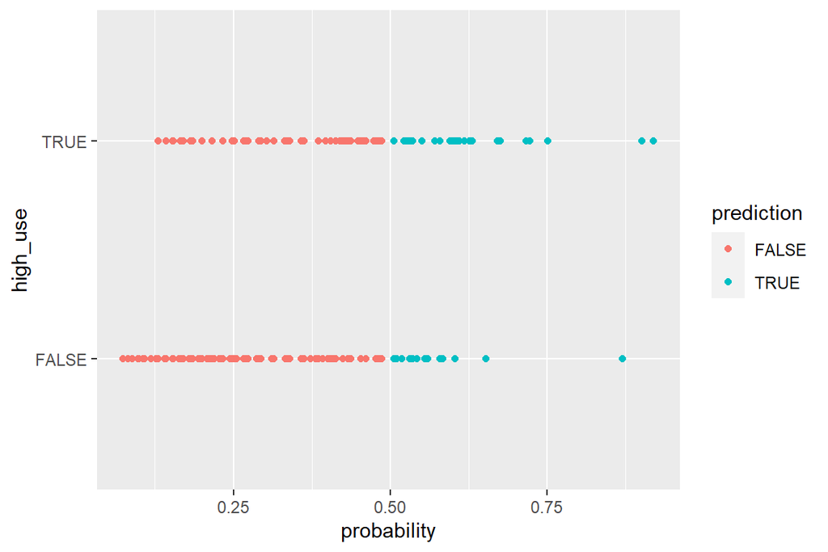

```r
g_p <- ggplot(alc_consump, aes(x = probability, y = high_use,col =prediction )) # initializing a plot of 'high_use' versus 'probability' in 'alc_consump'

 g_p + geom_point()# defining the geom as points and drawing the plot
```

```r
# tabulating the target variable versus the predictions
table(high_use = alc_consump$high_use, prediction = alc_consump$prediction) %>% prop.table() %>% addmargins()
```

```
##         prediction
## high_use      FALSE       TRUE        Sum
##    FALSE 0.66216216 0.03783784 0.70000000
##    TRUE  0.22432432 0.07567568 0.30000000
##    Sum   0.88648649 0.11351351 1.00000000
```

```r
loss_func <- function(class, prob) { # defining a loss function (mean prediction error)
  n_wrong <- abs(class - prob) > 0.5
  mean(n_wrong)
}

loss_func(class = alc_consump$high_use, prob = 0) # calling loss_func to compute the average number of wrong predictions in the data
```

```
## [1] 0.3
```

# 4. Clustering and classification

This week I performed clustering and classification. Below you can find the analysis that was performed, more information about the data that was analyzed and the results I got.

```r
date()
```

```
## [1] "Wed Dec 02 15:17:16 2020"
```

Exercises of week 4 are based on data from MASS library. Data Boston consists of housing Values in suburbs of Boston, and more information from the data can be found [here](https://stat.ethz.ch/R-manual/R-devel/library/MASS/html/Boston.html).

```r
library(MASS); library(tidyr); library(dplyr); library(ggplot2); library(GGally)
data("Boston") #reading data
str(Boston) # 506 obs. of  14 variables
```

```
## 'data.frame':    506 obs. of  14 variables:
##  $ crim   : num  0.00632 0.02731 0.02729 0.03237 0.06905 ...
##  $ zn     : num  18 0 0 0 0 0 12.5 12.5 12.5 12.5 ...
##  $ indus  : num  2.31 7.07 7.07 2.18 2.18 2.18 7.87 7.87 7.87 7.87 ...
##  $ chas   : int  0 0 0 0 0 0 0 0 0 0 ...
##  $ nox    : num  0.538 0.469 0.469 0.458 0.458 0.458 0.524 0.524 0.524 0.524 ...
##  $ rm     : num  6.58 6.42 7.18 7 7.15 ...
##  $ age    : num  65.2 78.9 61.1 45.8 54.2 58.7 66.6 96.1 100 85.9 ...
##  $ dis    : num  4.09 4.97 4.97 6.06 6.06 ...
##  $ rad    : int  1 2 2 3 3 3 5 5 5 5 ...
##  $ tax    : num  296 242 242 222 222 222 311 311 311 311 ...
##  $ ptratio: num  15.3 17.8 17.8 18.7 18.7 18.7 15.2 15.2 15.2 15.2 ...
##  $ black  : num  397 397 393 395 397 ...
##  $ lstat  : num  4.98 9.14 4.03 2.94 5.33 ...
##  $ medv   : num  24 21.6 34.7 33.4 36.2 28.7 22.9 27.1 16.5 18.9 ...
```

```r
dim(Boston) # 506 rows and 14 columns
```

```
## [1] 506  14
```

#### Graphical overview

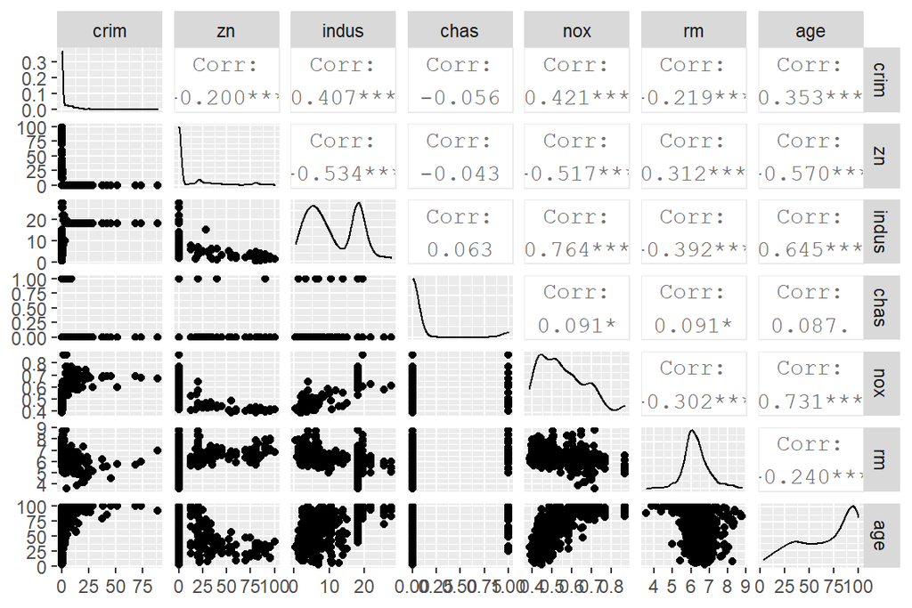

```r
ggpairs(Boston[1:7]) ## plotting matrix of the variables in two parts
```

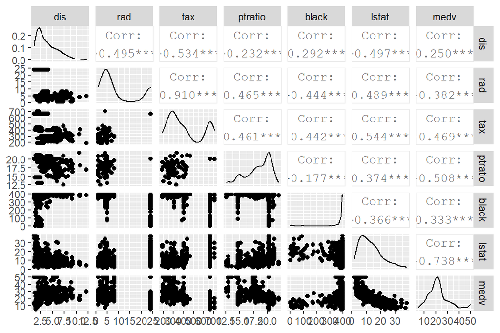

```r
ggpairs(Boston[8:14]) ## plotting matrix of the variables
```

From the pairs ggplots we can see the distributions and relationships between the variables. The biggest correlation in between variables tax and rad (0.910). Only the variable rm is somehow normally distributed. Distributions of variables crim, zn, chas, dis and lstat are on the left side. Whereas, Distribution of variableblack is in the right side. All the other variables, their distributions are somehow separated.